# boston_html

```python
import numpy as np
import pandas as pd
import matplotlib.pyplot as plt
import matplotlib.gridspec as gridspec
from sklearn.model_selection import KFold
```

## A quick project using the Boston Housing data set.

I know it's been done to death but just about everyone who works in ML (or is aspiring to do so) has had their hands on this data at some point.

Also I may have removed one or two features from the data that I found distasteful.

Our target variable is the median value of homes (MEDV). The data is split up by district. So basically we want to use things like crime-rate, student-to-teacher ratio, etc. to predict the median value of homes in a particular district.

### Step 1: Load the data

```python
df = pd.read_csv(r'boston_housing.csv', index_col=None)
df.head()
```

|  | crim | zn | indus | chas | nox | rm | age | dis | rad | tax | ptratio | lstat | medv |
| --- | --- | --- | --- | --- | --- | --- | --- | --- | --- | --- | --- | --- | --- |
| 0 | 0.00632 | 18.0 | 2.31 | 0 | 0.538 | 6.575 | 65.2 | 4.0900 | 1 | 296 | 15.3 | 4.98 | 24.0 |
| 1 | 0.02731 | 0.0 | 7.07 | 0 | 0.469 | 6.421 | 78.9 | 4.9671 | 2 | 242 | 17.8 | 9.14 | 21.6 |
| 2 | 0.02729 | 0.0 | 7.07 | 0 | 0.469 | 7.185 | 61.1 | 4.9671 | 2 | 242 | 17.8 | 4.03 | 34.7 |
| 3 | 0.03237 | 0.0 | 2.18 | 0 | 0.458 | 6.998 | 45.8 | 6.0622 | 3 | 222 | 18.7 | 2.94 | 33.4 |
| 4 | 0.06905 | 0.0 | 2.18 | 0 | 0.458 | 7.147 | 54.2 | 6.0622 | 3 | 222 | 18.7 | 5.33 | 36.2 |

### Step 1.5

After loading the data, create separate objects for the features and the target variable

```python
# drop the target variable because it is not a feature
Xd = df.drop(columns=['medv'])

# get the array of values from the dataframe
X = Xd.values

# create a separate array for the target variable
y = df.medv.values
```

#### Next, let's create a method to scale the features

Using the Z-score method:

$$ x_{j}^{(i)} = \frac{x_j^{(i)} - \mu_j}{\sigma_j} $$

We will use this function later to help make gradient descent run more predictably.

```python
def normalize_features(X):
    # calculate the mean and standard deviation by column in our matrix of features
    mu_j = np.mean(X, axis=0)
    sigma_j = np.std(X, axis=0)

    # get the array of normalized features
    X_norm = (X - mu_j) / sigma_j

    return X_norm
```

#### Now let's get a dataframe containting the features that we want to include in our computation

```python
# name the variables you want
# df_choice = df[["crim", "indus", "nox", "age", "rad", "tax"]]

# or just take them all ;)
df_choice = Xd

# n = X_norm.shape[1]  # the number of features + x_0 (which is always 1!)
df_choice.head()
```

|  | crim | zn | indus | chas | nox | rm | age | dis | rad | tax | ptratio | lstat |
| --- | --- | --- | --- | --- | --- | --- | --- | --- | --- | --- | --- | --- |
| 0 | 0.00632 | 18.0 | 2.31 | 0 | 0.538 | 6.575 | 65.2 | 4.0900 | 1 | 296 | 15.3 | 4.98 |
| 1 | 0.02731 | 0.0 | 7.07 | 0 | 0.469 | 6.421 | 78.9 | 4.9671 | 2 | 242 | 17.8 | 9.14 |
| 2 | 0.02729 | 0.0 | 7.07 | 0 | 0.469 | 7.185 | 61.1 | 4.9671 | 2 | 242 | 17.8 | 4.03 |
| 3 | 0.03237 | 0.0 | 2.18 | 0 | 0.458 | 6.998 | 45.8 | 6.0622 | 3 | 222 | 18.7 | 2.94 |
| 4 | 0.06905 | 0.0 | 2.18 | 0 | 0.458 | 7.147 | 54.2 | 6.0622 | 3 | 222 | 18.7 | 5.33 |

### Data Visualization

I personally like to see how individual features correlate with the target variable as a first step in building intuition. This would be really important if we wanted to try engineering some new features.

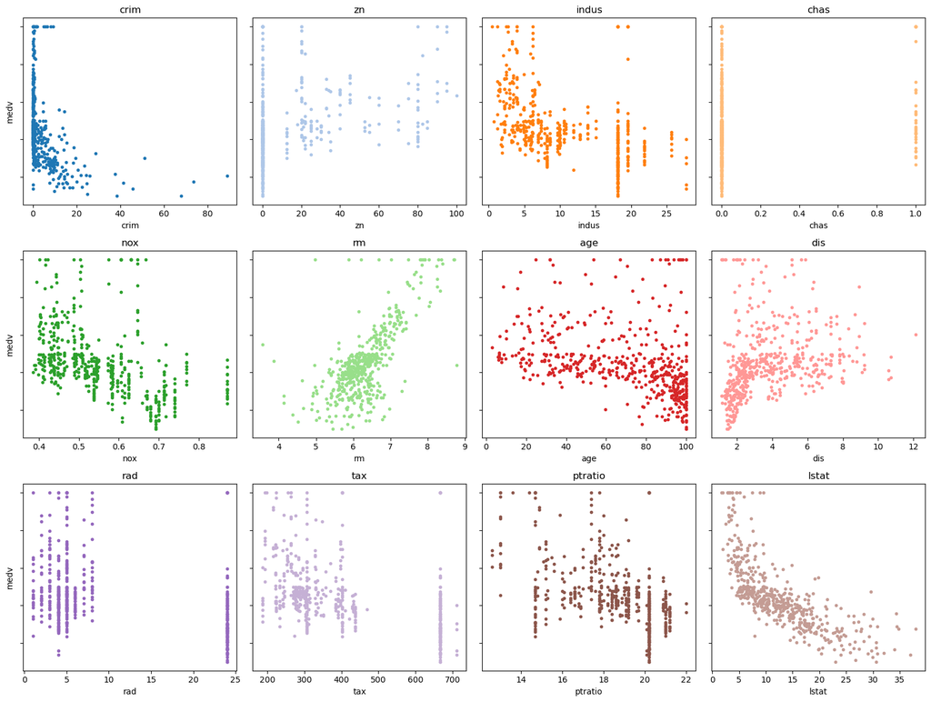

```python
# Create a figure and axes object
fig, axes = plt.subplots(3, 4, figsize=(16, 12), sharey=True)

# Get the number of features
num_features = len(df.columns)-1

# Create a list of colors
colors = plt.get_cmap('tab20')(range(num_features))

# Loop through each feature
for i, col in enumerate(df.columns[:-1]):
    ax = axes[i//4, i%4]
    ax.scatter(df[col], df['medv'], color=colors[i], marker='.')
    ax.set_xlabel(col)
    if i % 4 == 0:
        ax.set_ylabel('medv')
    else:
        ax.set_yticklabels([])
        ax.set_ylabel('')
    ax.set_title(col)

# Adjust the spacing between the subplots
fig.tight_layout()

plt.show()
```

#### Now let's use the sklearn package we imported to break the data up into subsets for 10-fold validation

```python
# extract the array from our dataframe of choice variables
X = df_choice.values

# create the kfold object
kf = KFold(n_splits=10, shuffle=True, random_state=0)

# each element of folds will contain the indices for a training set and a testing set
folds = list(kf.split(X))
```

### Homebrew Gradient Descent

In the implementation of gradient descent, it was helpful to break the algorithm up into several subroutines. Directly below we have done that, producing methods both to compute cost and all of it's partial derivatives.

Although not strictly necessary, vectorized code substantially improves the running time of gradient descent. This data set contains 506 rows of features and vectorizing the code as is done below takes the running time from over an hour down to just a few seconds.

#### The cost function $$J(θ) = \frac{1}{2m}\sum_{i=1}^m \left[ h_θ(\mathbf{\vec{x}^{(i)})-y^{(i)}} \right]^2 $$ may be vectorized like this:

#### $$ J(θ) = \frac{1}{2m}(Xθ-\vec{y})^T(Xθ-\vec{y}) $$

```python
def cost(X, y, theta, m, n):
    '''
    X - your normalized matrix containing m rows of n features including x_0 always set to 1
    y - your 1-D array containing m target variable instances
    theta - the 1-D array of weights including the bias (intercept)
    m - the number of oberservations (num rows in X)
    n - the number of features (num columns in X)
    '''
    # there are probably some redundant parentheses here
    return (1/2*m) * (np.transpose(X@theta - y)@(X@theta - y))
```

#### The derivative of the cost function can be vectorized this way $$ \left< \frac{\partial J(\theta)}{\partial\theta_1}, \frac{\partial J(\theta)}{\partial\theta_2}, ..., \frac{\partial J(\theta)}{\partial\theta_n}\right> = \frac{1}{m}X^T(X\theta - \vec{y}) $$

```python
def derivative(X, y, theta, m):
    return (1/m)*(X.T@(X@theta - y))
```

## Putting It All Together

```python
def gradient_descent(X, y, m, n, k=10):
    '''
    a - the learning rate
    X - your normalized matrix containing m rows of n features including x_0 always set to 1
    y - your 1-D array containing m target variable instances
    theta - the 1-D array of weights including the bias (intercept)
    epsilon - if iter_diff < epsilon, then we terminate the loop
    iter - the current iteration number
    num_iters - the max number of iterations
    iter_diff - |previous_cost - current_cost| / current_cost
    m - the number of oberservations (num rows in X)
    n - the number of features (num columns in X)
    k - the interval at which you would like to keep a record of cost
    cost_history - keeps a record of the cost function output at each kth iteration of gradient descent
    '''
    a = 0.003
    theta = np.ones(n)
    epsilon = .00005
    num_iters = 100000
    iter = 0
    cost_history = []
    current_cost = 0
    iter_diff = 1

    while epsilon < iter_diff:
        if iter >= num_iters:
            break
        theta = theta - a*derivative(X, y, theta, m)
        previous_cost = current_cost
        current_cost = cost(X, y, theta, m, n)
        iter_diff = abs(current_cost-previous_cost)/current_cost
        if (iter%k == 0):
            cost_history.append(current_cost)
        iter = iter + 1
    return (theta, cost_history)
```

### Now we're set up to train and test the model on each of the different folds.

```python
interval = 30  # interval is an optional argument for gradient_descent() that tells how often you want a snapshot of the process
predictions = [] # a list of arrays, each of which contains the predictions for one of the folds
fold_error = []  # stores the avg percent error for the predictions made on this fold

for fold in folds:

    train, test = fold[0], fold[1]

    # get subsets of training and testing data for current fold
    x_train = X[train]
    y_train = y[train]
    x_test = X[test]
    y_test = y[test]

    # the number of observations in this training set
    m = len(x_train)

    # normalize the features of the observations in the training/testing sets
    x_train = normalize_features(x_train)
    x_test = normalize_features(x_test)

    # adding θx=1 for x_0, θ_0
    x_train = np.c_[np.ones(m), x_train]
    x_test = np.c_[np.ones(len(x_test)), x_test]

    # the number of features in x_train
    n = x_train.shape[1]

    # optimize the weight vector by running gradient descent
    out = gradient_descent(x_train, y_train, m, n, interval)
    theta_hat, cost_history = out[0], out[1]

    # make predictions
    prediction = x_test.dot(theta_hat)
    predictions.append(prediction)
    err = sum(abs(prediction - y_test))/len(y_test)
    fold_error.append(err)
```

### Now that we have made predictions for each of the ten test sets, let's compare those predictions to the labels and see how we did.

```python
# calculate how far off our predictions were across all 10 folds on average
average_error = round(sum(fold_error)/len(fold_error), 2)
print(f"avg error: {average_error}%")
```

```
avg error: 3.55%
```

Or, at least is seems that way...  
But how do we really know how good we are? We should compare our result to a standard benchmark to see if all the extra effort was really worth it. The most obvious naive method here would be to simply take the average value of MEDV (our target variable) and predict that average for each case. Well let's do just that and see what happens...

```python
naive_err = round(sum(abs(y - np.mean(y)))/len(y), 2)
print(f'naive method avg error: {naive_err}%')
```

```
naive method avg error: 6.65%
```

### And just for fun, here is a visual for the gradient decent algorithm, plotting the output of the cost function once every 30 iterations

It took me a lot of trial and error to get the algorithm to run smoothly and converge. Getting to see this nice curve when it finally happened was quite satisfying.

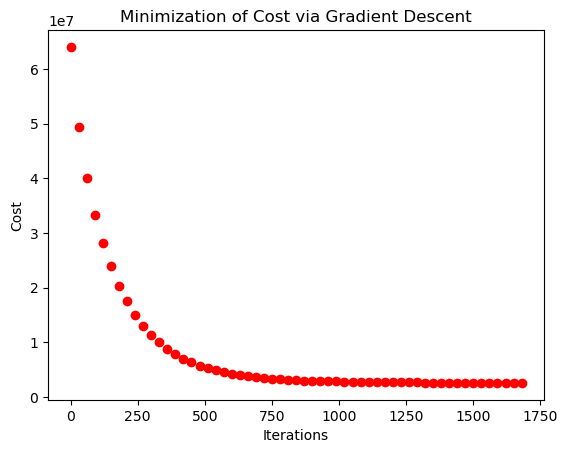

```python
iterations = [i*interval for i in range(len(cost_history))]
plt.scatter(iterations, cost_history, color='red')
plt.xlabel("Iterations")
plt.ylabel("Cost")
plt.title("Minimization of Cost via Gradient Descent")
plt.show()
```

References :  
https://towardsdatascience.com/vectorization-implementation-in-machine-learning-ca652920c55d  
https://www.coursera.org/learn/machine-learning/home/info